# Assignment 1

Mauricio Reis | D21125621

Complete the following project using R Markdown and ensure that your code and output are readable in the html file.

### The `gangs` network dataset

Criminal (sub)network of 67 gang members of Balkan crime groups in Italy. The following vertex attributes are provided:

- `nationality`: nationality of the criminal (1 = Serbian, 2 = Romanian, 3 = Greek, 4 = Bulgarian);
- `sex`: sex of the criminal (1 = female, 2 = male);
- `role`: role of the criminal (1 = leader, 2 = ‘thug’, 3 = ‘lackie’).

```r
library(statnet)
load(url("https://acaimo.github.io/Bergm/network_data/gangs.Rdata"))
```

```r
#helper functions
nationalityList <- c('Serbian', 'Romanian', 'Greek', 'Bulgarian')
nationalityColList <- c('Red', 'Yellow', 'Blue', 'Green')
sexList <- c('female', 'male')
sexColList <- c('pink', 'blue')
roleList <- c('leader', 'thug', 'lackie')
roleColList <- c('gold', 'grey', 'brown')
describeNode <- function(nodeNumber) {

  nationality <- (y %v% "nationality")[nodeNumber]
  sex <- (y %v% "sex")[nodeNumber]
  role <- (y %v% "role")[nodeNumber]
  paste("Node ", nodeNumber, " - ",
        "nationality: ", nationalityList[nationality], ", ",
        "sex: ",  sexList[sex], ", ",
        "role: ", roleList[role], sep = "")
}
```

### Description

Calculate and interpret:

1. the density of the network; [**10 marks**]

```r
y <- gangs
summary(y ~ density)
```

```
##    density
## 0.01650837
```

*Comment*  
This value represents the number of edges divided by the number of dyads on the network and serves to assert if a network is dense or sparse. This network is sparse with $density < 0.5$

2. in- and out- degree distribution, plot the respective histograms, and identify the node(s) with the highest degree measures; [**10 marks**]

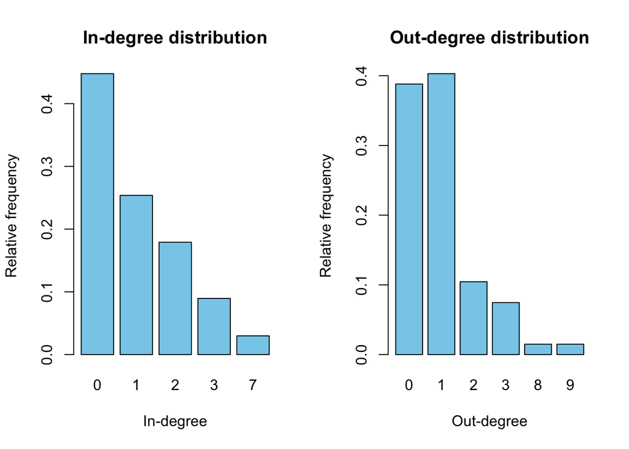

```r
id_i <- degree(y, cmode = "indegree")
od_i <- degree(y, cmode = "outdegree")
numVertex <- length(network.vertex.names(y))
par(mfrow = c(1, 2))


barplot(table(id_i) / numVertex,
        main = "In-degree distribution",
        col = "skyblue",
        xlab = "In-degree",
        ylab = "Relative frequency")

barplot(table(od_i) / numVertex,
        main = "Out-degree distribution",
        col = "skyblue",
        xlab = "Out-degree",
        ylab = "Relative frequency")
```

```r
nodesWithMaximumInDegree <- which(id_i == max(id_i))
nodesWithMaximumOutDegree <- which(od_i == max(od_i))
print("The node(s) with maximum In Degree is/are:")
```

```
## [1] "The node(s) with maximum In Degree is/are:"
```

```r
print(sapply(nodesWithMaximumInDegree,describeNode))
```

[output not shown]

```r
print("The node(s) with maximum Out Degree is/are:")
```

```
## [1] "The node(s) with maximum Out Degree is/are:"
```

```r
print(sapply(nodesWithMaximumOutDegree,describeNode))
```

[output not shown]

*Comment*

From the histogram above we can notice that the most common by far for a node in the network is to receive (in) 0 connections. In the case of a node pointing out to another node (out), the most common is point out to 1 other node closely followed by 0.

We also discovered that the nodes with the maximum In Degree are 30 (a Serbian female lackie) and 57 (a Bulgarian female thug) and the node with the maxium Out degree is also the 57.

3. the geodesic distances of the network; [**10 marks**]

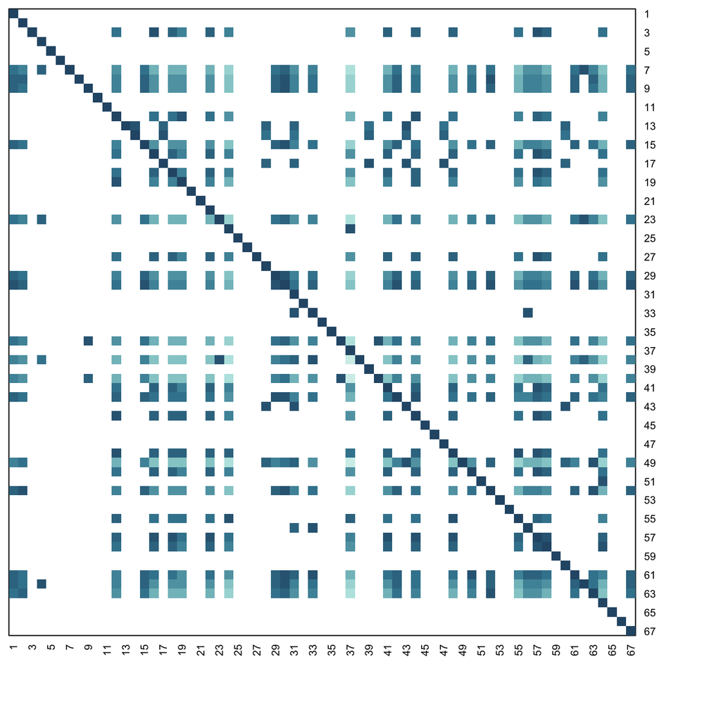

```r
gd <- geodist(y)$gdist

cp <- hcl.colors(nlevels(factor(gd)), "Teal")

heatmap(gd,
        Rowv = NA, Colv = "Rowv",
        symm = TRUE,
        col = cp,
        frame = TRUE)
```

*Comment*

As you can see in the heapmap above, there is not one single node in this network that connect with all the other nodes (we at least a few blank spaces on every line). We can also notice the diagonal dark line that shows for each position where the node references itself. The varied colours show that we have some nodes connecting with others through a long path (lighter colours) and others through a short path (darker colours)

4. the betweenness centrality (and plot it) and identify the nodes with the highest values of this measure; [**10 marks**]

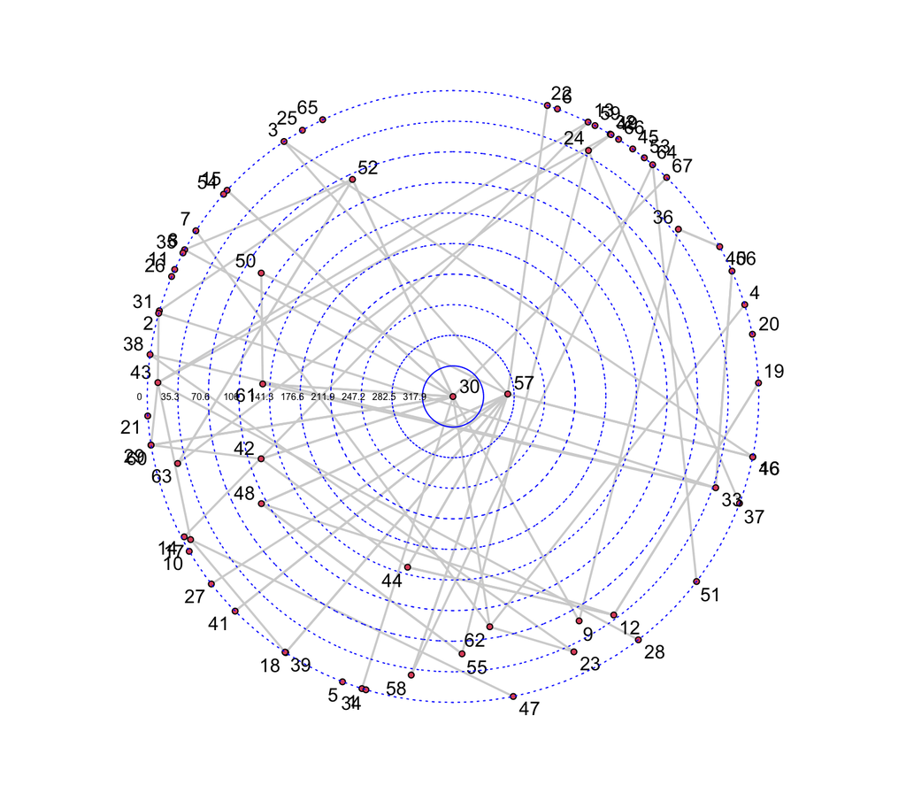

```r
set.seed(2)
par(mar = rep(0, 4))
gplot.target(y[, ],
             betweenness(y),
             gmode = "graph",
             label = 1:length(network.vertex.names(y)),
             vertex.cex = 0.3,
             edge.col = 'lightgrey',
             label.cex = 1,
             circ.lab.cex = 0.5)
```

```r
describeNode(which.max(betweenness(y)))
```

[output not shown]

*Comment*  
The node with the highest value for betweenness centrality is node 30 (a Serbian female lackie), followed by node 57 (a Bulgarian female thug). This means that those two gang members are the top 2 the shortest paths to connect other gang members (in terms of how many can go through this path, not necessarily that everyone can or has this as the shortest path to any other member).

5. the clustering coefficient of the network; [**10 marks**]

```r
gtrans(y[, ],
       mode = "digraph")
```

```
## [1] 0.04294479
```

*Comment*  
Clustering coeficient is the number of triangles in a network divided by the number of connected triples.

Given that a clustering coeficient of 1 means that on our context “if gang member x is connected with member y, and member y is connect with member z, so member x is connected with member z”, this value 0.0429 means that this is not that case in most of the times

6. the **edgewise** reciprocity between criminals with the same nationality (hint: `mutual(same = ...)`). [**10 marks**]

```r
summary(y ~ edges + mutual(same = "nationality") + nodematch("nationality"))
```

```
##                 edges    mutual.nationality nodematch.nationality
##                    73                    14                    59
```

```r
reciprocity <- 14/73
reciprocityNationalityOnly <- 14/59
print(paste("Reciprocity", reciprocity))
```

```
## [1] "Reciprocity 0.191780821917808"
```

```r
print(paste("Reciprocity considering nationality only", reciprocityNationalityOnly))
```

```
## [1] "Reciprocity considering nationality only 0.23728813559322"
```

*Comment*

Reciprocity is the number of mutual edges divided by the number of edges in the network. For the gangs dataset we found 14 mutual edges among a total of 73 edges in the network giving a reciprocity of 0.192. If we consider only the edges that have a matching nationality instead of all edges though, then this number goes up to 0.237.